# Analysis of Climate Justice literature

Quinn Asena

# Introduction

This document is the output of a reproducible workflow for the bibliometric and topic analysis supporting the submitted publication. Included in the repository hosted on figshare is the source code and additional analyses including figures not included in the main text.

# Corpus overview

## Publication types (books, artilces…) before filtering

Plotting results **before filtering**

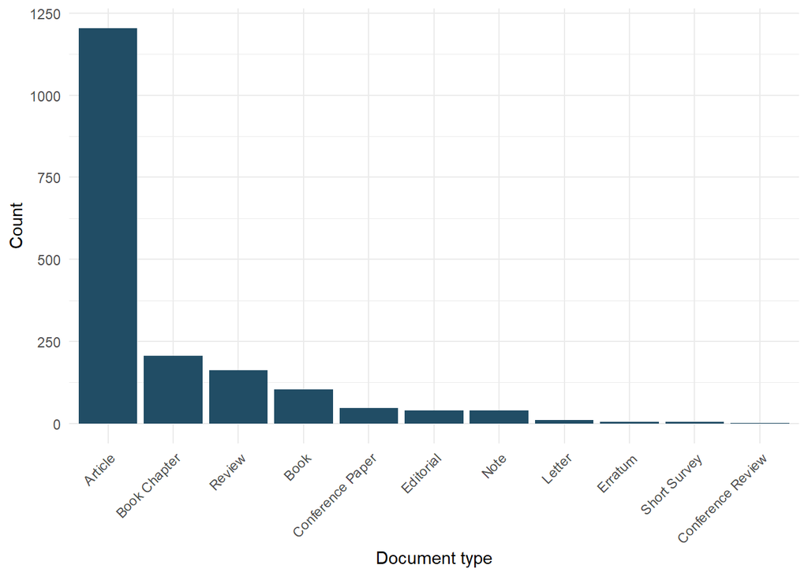

## Filtering

Initial results: 1827

- Filtering to keep: “Article”, “Review”, “Book Chapter”, “Book”, “Conference Paper”, “Note”
- Filtering to remove results with no abstract/text to analyse

After filtering: 1683 remain.

### Table of results

Results *after filtering*.

date range of results: 1997-01-01, 2021-12-01

| subtype_description | n | prop |
| --- | --- | --- |
| Article | 1167 | 0.69340463 |
| Review | 156 | 0.09269162 |
| Note | 18 | 0.01069519 |
| Book | 104 | 0.06179441 |
| Book Chapter | 192 | 0.11408200 |
| Conference Paper | 46 | 0.02733214 |

## Top 15 most popular journals

Environmental Justice journal established in March 2008.

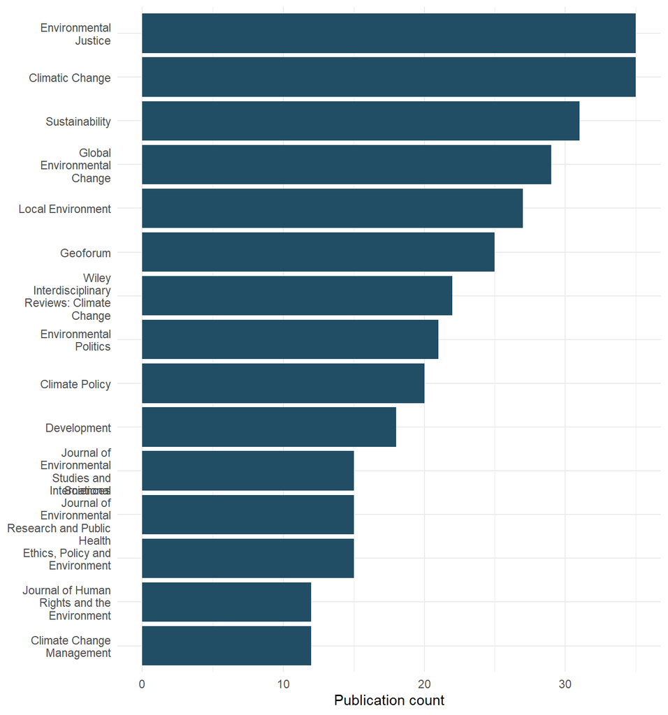

Number of publications from the top 15 journals

| source_id | n | prism_publication_name |
| --- | --- | --- |
| 11600153918 | 35 | Environmental Justice |
| 12177 | 35 | Climatic Change |
| 21100240100 | 31 | Sustainability |
| 36483 | 29 | Global Environmental Change |
| 14506 | 27 | Local Environment |
| 28611 | 25 | Geoforum |
| 19900191605 | 22 | Wiley Interdisciplinary Reviews: Climate Change |
| 24519 | 21 | Environmental Politics |
| 22524 | 20 | Climate Policy |
| 14090 | 18 | Development |

[output cut: 5 more lines]

## Publications through time

**Figure truncated to 2020**.

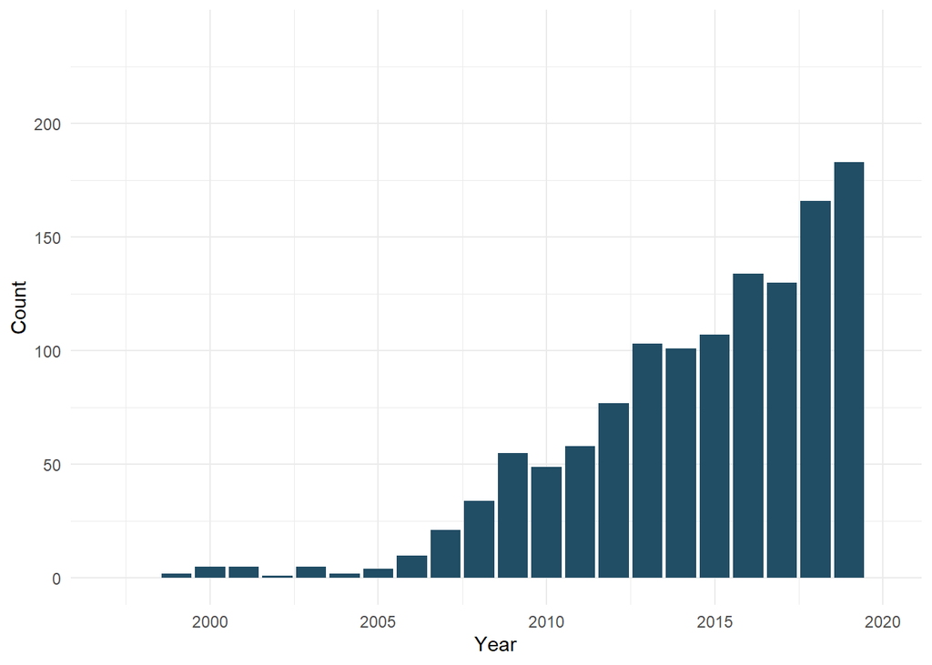

Table of the number of publications through time.

| year | count |
| --- | --- |
| 2021-01-01 | 192 |
| 2020-01-01 | 238 |
| 2019-01-01 | 183 |
| 2018-01-01 | 166 |
| 2017-01-01 | 130 |
| 2016-01-01 | 134 |
| 2015-01-01 | 107 |
| 2014-01-01 | 101 |
| 2013-01-01 | 103 |
| 2012-01-01 | 77 |

[output cut: 14 more lines]

Publications through time normalised to 2010: Shows the growth of publications on climate justice (dark purple) relative to publications in all of science (red) and the environment subject area (blue). Figure truncated to 2020.

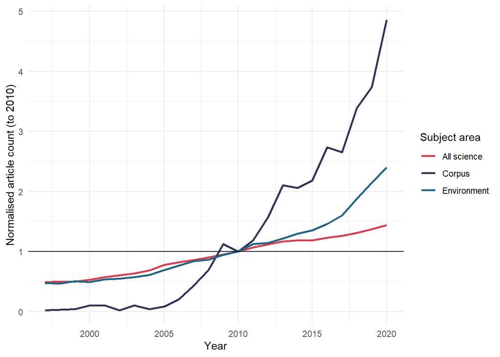

## Mean number of authors through time

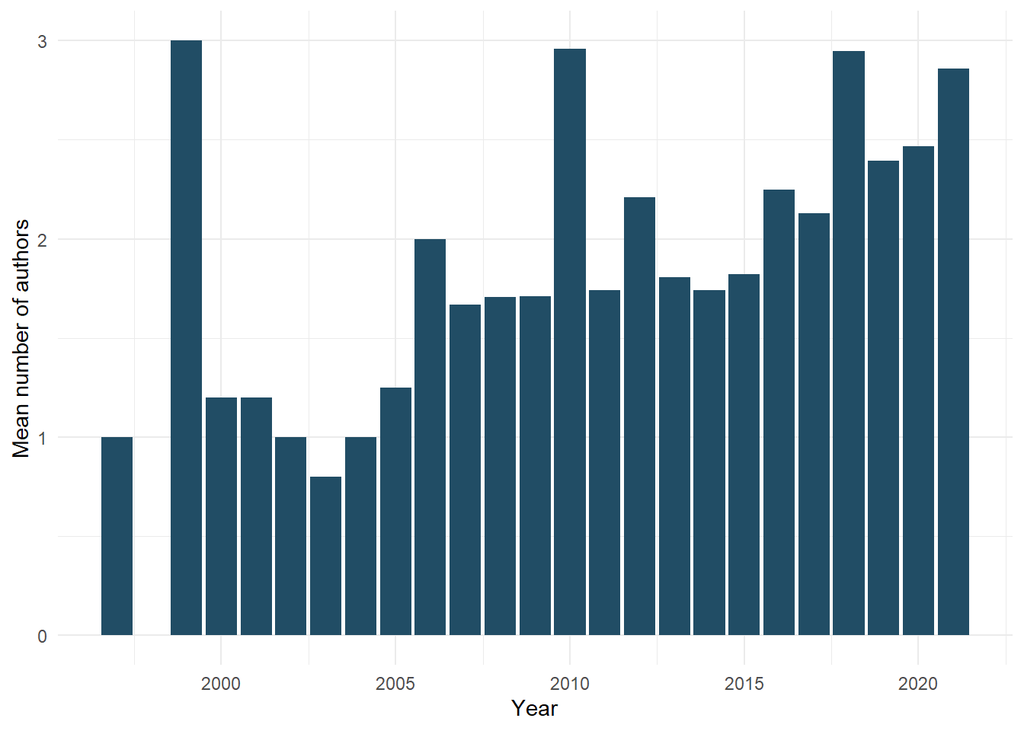

Table of mean authors through time:

| year | mean_auth |
| --- | --- |
| 2021-01-01 | 2.859375 |
| 2020-01-01 | 2.466387 |
| 2019-01-01 | 2.393443 |
| 2018-01-01 | 2.945783 |
| 2017-01-01 | 2.130769 |
| 2016-01-01 | 2.246269 |
| 2015-01-01 | 1.822430 |
| 2014-01-01 | 1.742574 |
| 2013-01-01 | 1.805825 |
| 2012-01-01 | 2.207792 |

[output cut: 14 more lines]

## Most productive authors

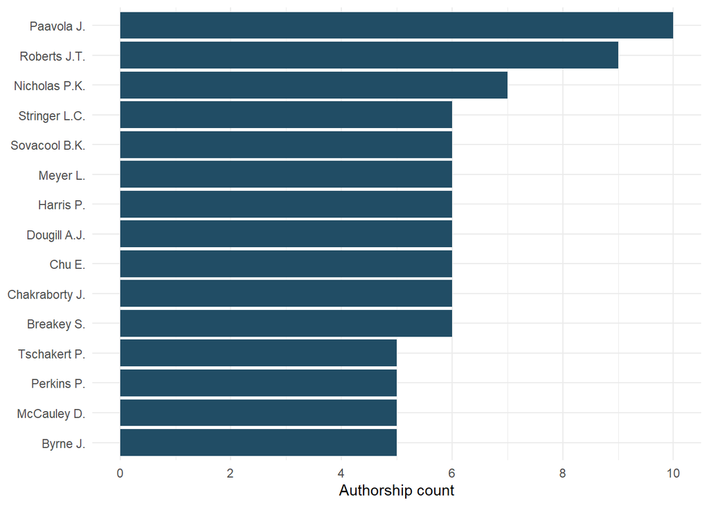

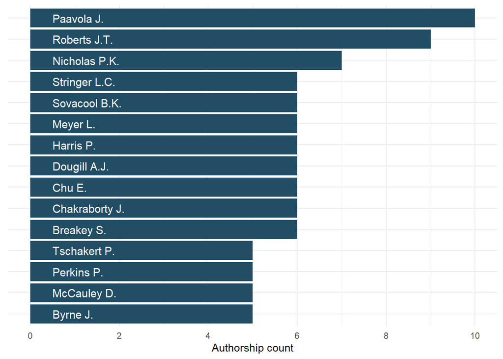

| authname | n |
| --- | --- |
| Paavola J. | 10 |
| Roberts J.T. | 9 |
| Nicholas P.K. | 7 |
| Stringer L.C. | 6 |
| Harris P. | 6 |
| Breakey S. | 6 |
| Chu E. | 6 |
| Dougill A.J. | 6 |
| Chakraborty J. | 6 |
| Meyer L. | 6 |

[output cut: 5 more lines]

## Most cited papers

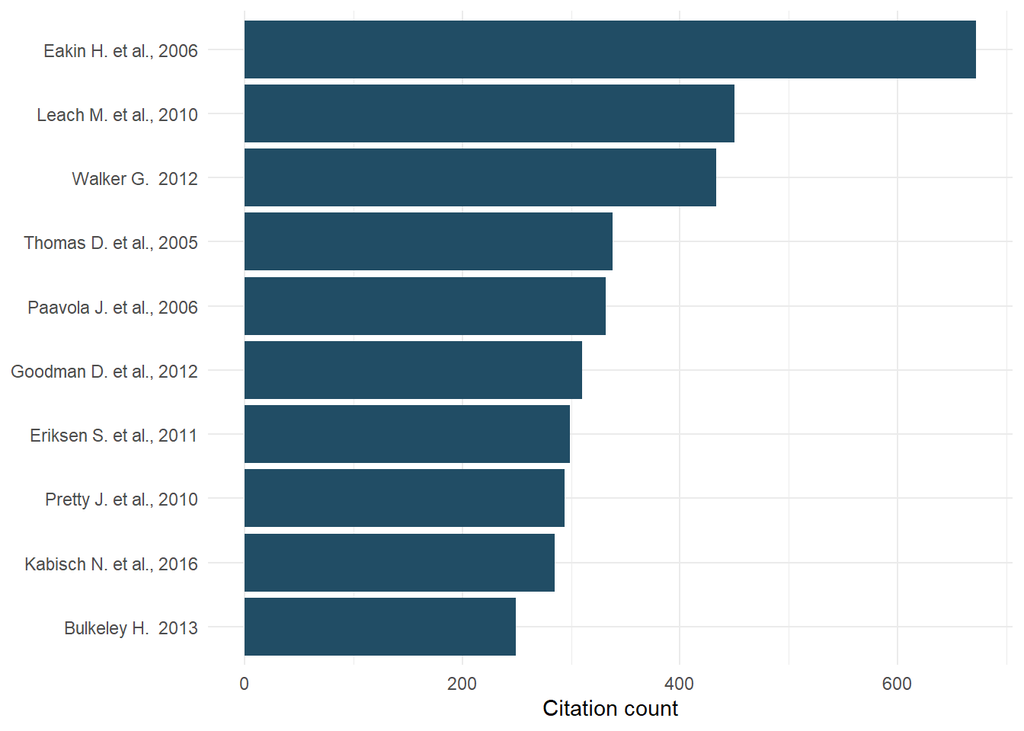

## Most productive countries

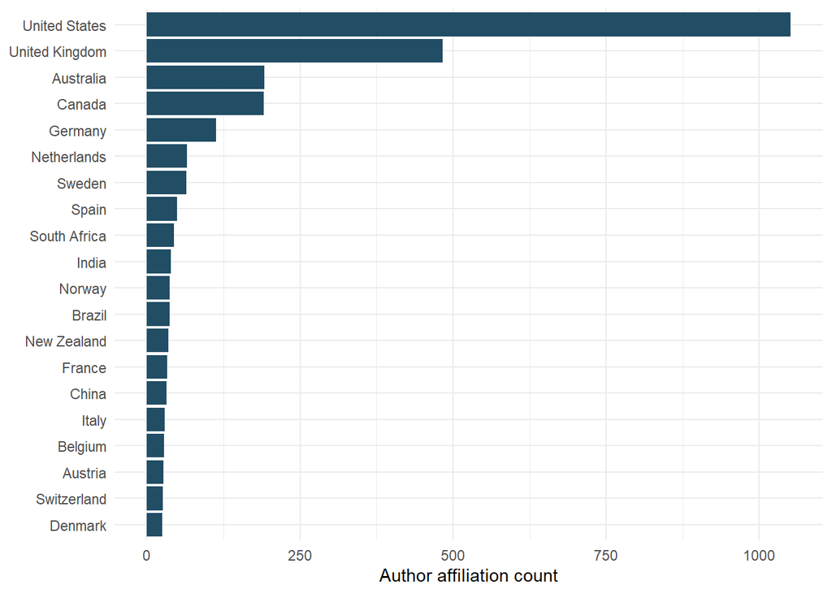

| affiliation_country | n |
| --- | --- |
| United States | 1051 |
| United Kingdom | 483 |
| Australia | 192 |
| Canada | 191 |
| Germany | 113 |
| Netherlands | 65 |
| Sweden | 64 |
| Spain | 49 |
| South Africa | 44 |
| India | 39 |

[output cut: 5 more lines]

# Corpus analysis

## Most common words in abstracts.

Exploratory plot. No surprises, good check for unexpected common words.

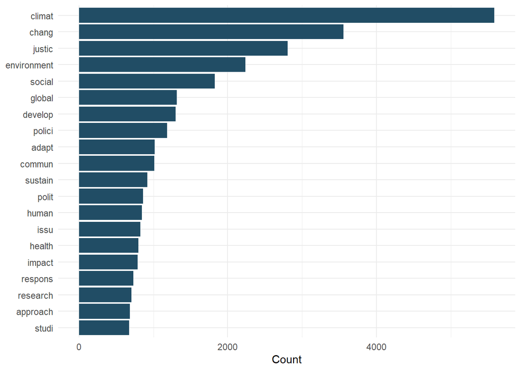

## Most common word pairs in abstracts

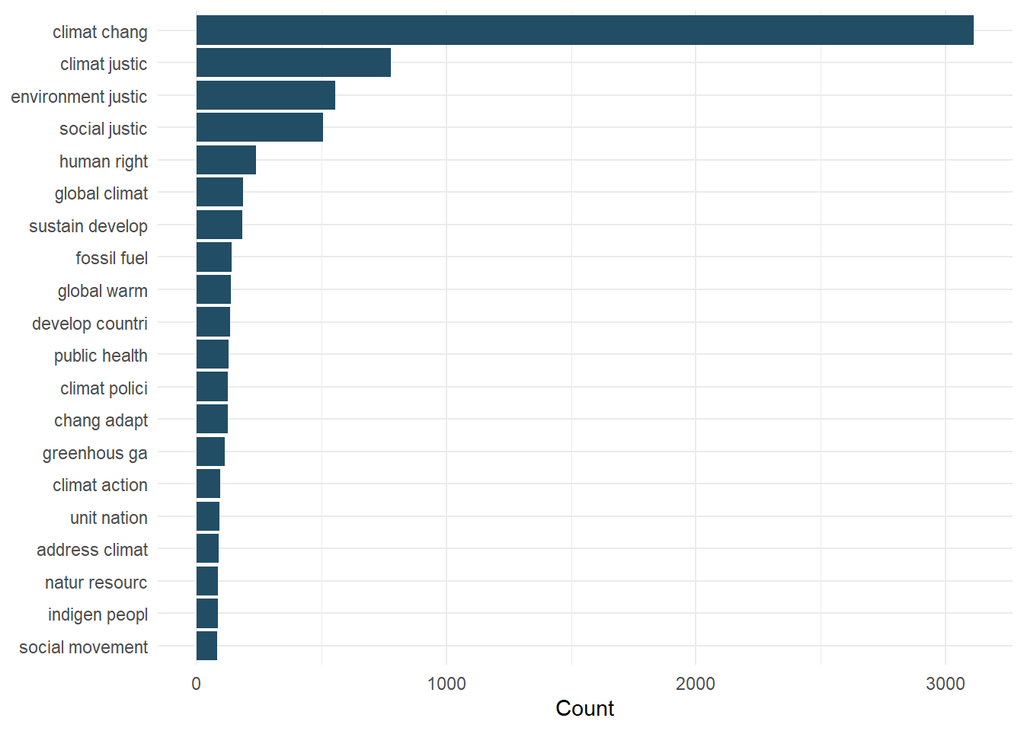

## Network of word pairs

Network graph of most commonly joined words. “Note that this is a visualization of a Markov chain, a common model in text processing, where the choice of a word only depends on its previous word”.

The bigram count values have been log transformed to show a stronger colour gradient in the visualisation but the labels show the true count.

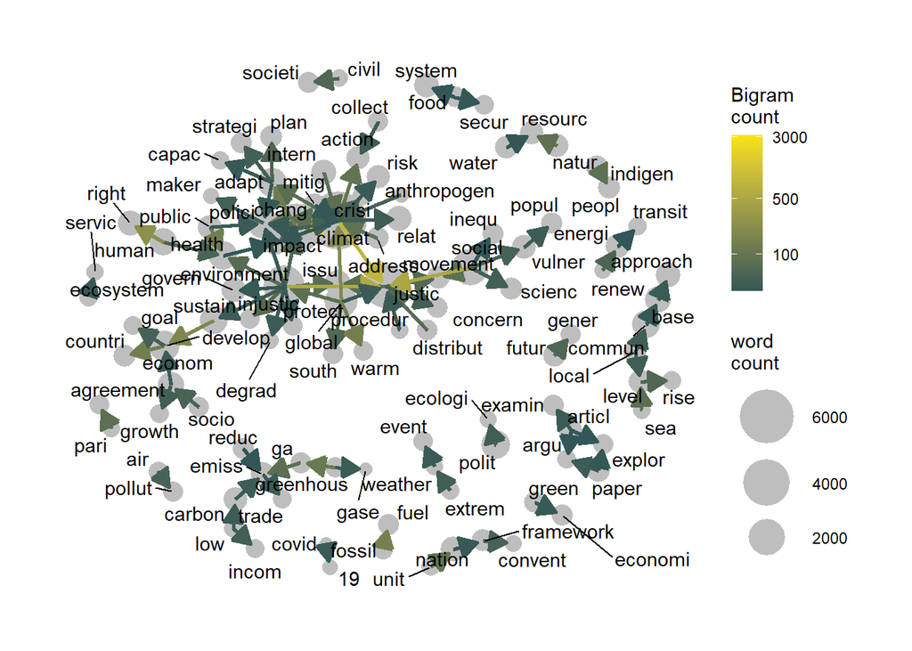

# Correlating word pairs

Shows expected result; however, individual abstracts too small to be robust. Ultimately excluded as unnecessary from final results.

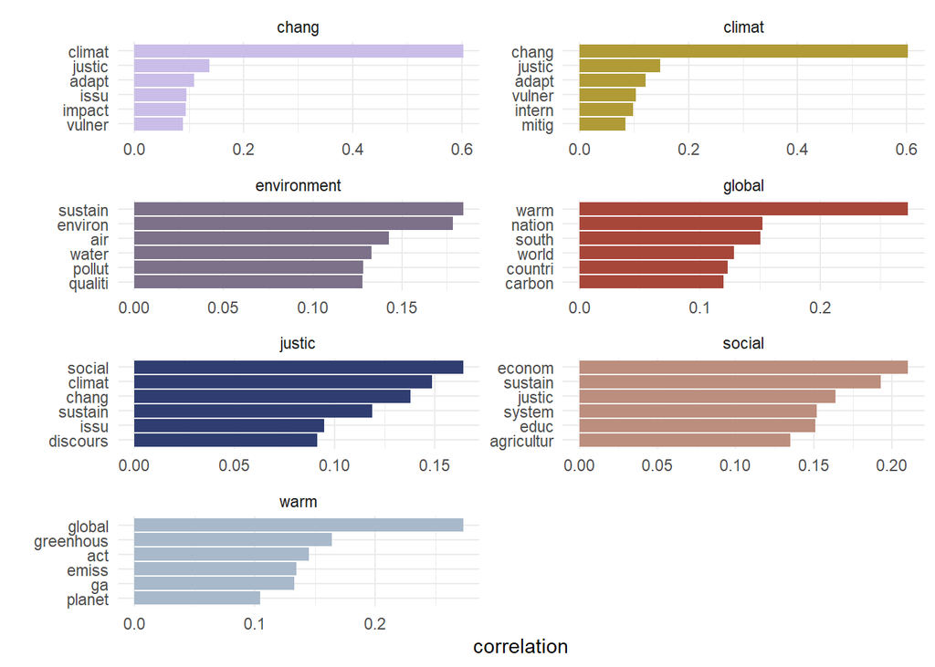

# Author keywords

Most common keywords used by Authors. 494 documents out of 1683 do not have keywords.

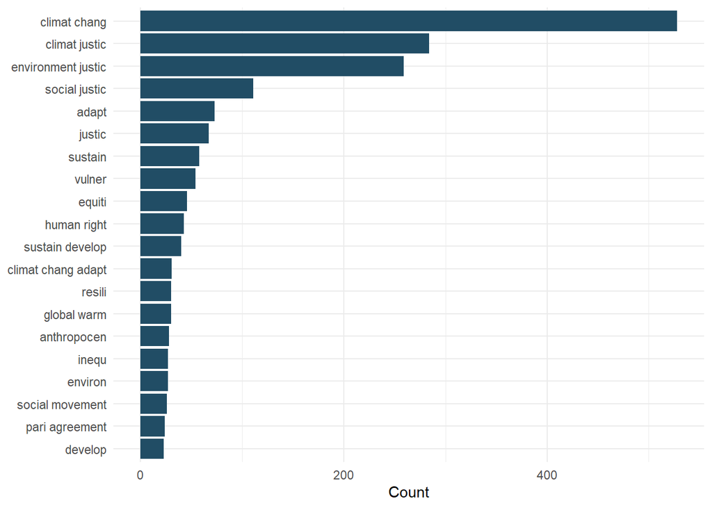

# Frequency of search terms in abstract over time

Shows strong patterns in search terms over time (note that there are only a few publications in early years). Excluded from main text as the focus of the work is on trends in *topics*.

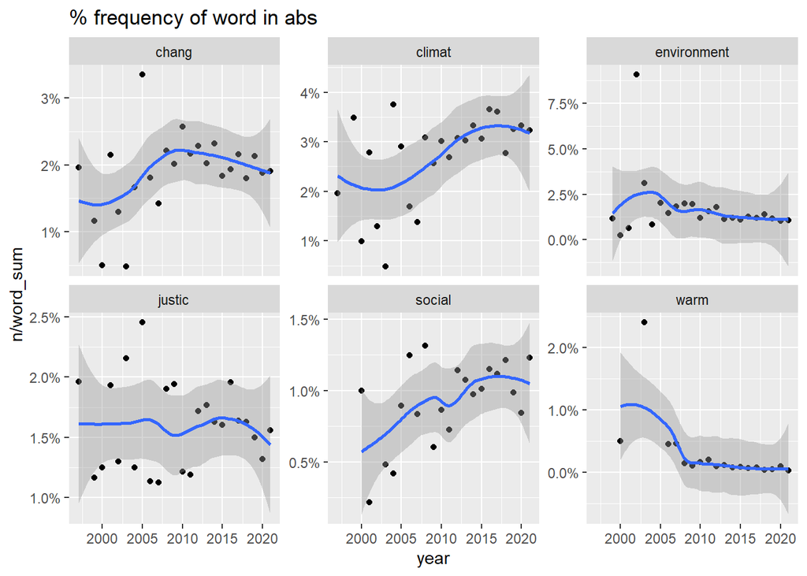

# LDA

To explore the topics within the corpus, search terms (climate, change, justice, social, environmental, global, and warming) have been excluded from the topic model. Other frequent but not meaningful terms (i.e., article, research and studies) have also been removed.

```
## A topic model with 6 topics, 1683 documents and a 9620 word dictionary.
```

```
## Topic 1 Top Words:
##       Highest Prob: educ, sustain, food, student, scienc, book, agricultur
##       FREX: student, farmer, speci, heritag, creativ, teacher, soil
##       Lift: agroecolog, ander, apocalypt, aquif, attrit, author’, beck
##       Score: educ, student, book, teach, food, music, teacher
## Topic 2 Top Words:
##       Highest Prob: sustain, develop, approach, issu, human, paper, practic
##       FREX: tourism, philosophi, sdg, literatur, concept, ethic, conceptu
##       Lift: confucian, mayan, ecg, ecumen, encycl, ontolog, philosophi
##       Score: ethic, tourism, sustain, moral, daylight, human, ecg
## Topic 3 Top Words:
##       Highest Prob: polici, develop, emiss, countri, intern, carbon, mitig
##       FREX: financ, unfccc, parti, compens, eu, agreement, cap
##       Lift: 0.04, 0.12, 1,227, 10.2, 1011, 104, 105
##       Score: emiss, carbon, unfccc, compens, agreement, pari, negoti
## Topic 4 Top Words:
##       Highest Prob: adapt, health, commun, vulner, urban, impact, risk
##       FREX: heat, exposur, resid, censu, urban, extrem, citi
##       Lift: 0.001, 0.002, 0.006, 0.008, 0.010, 0.013, 0.016
##       Score: health, urban, adapt, heat, exposur, flood, citi
## Topic 5 Top Words:
##       Highest Prob: polit, movement, energi, power, govern, frame, commun
##       FREX: contest, feminist, divest, labour, transit, redd, intersect
##       Lift: agit, attun, auster, corpu, drr, fff, guilt
##       Score: movement, activist, energi, redd, transit, divest, feminist
## Topic 6 Top Words:
##       Highest Prob: right, human, law, indigen, peopl, legal, resourc
##       FREX: coal, court, litig, jurisdict, law, cc, tribal
##       Lift: abrupt, adger, adjoin, ai, amend, backward, biocapac
##       Score: law, litig, right, court, legal, coal, indigen
```

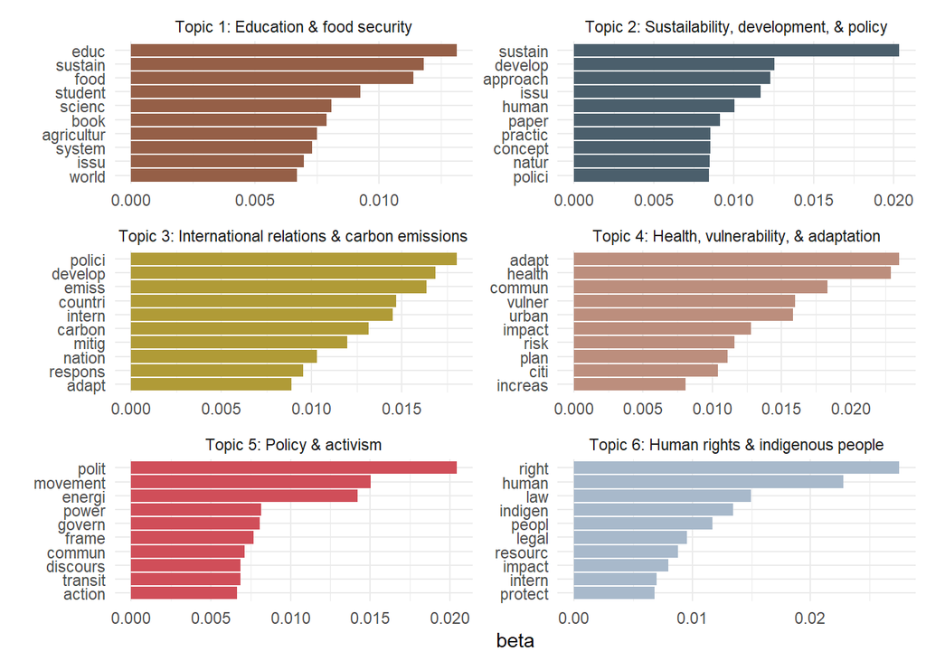

## Four to ten topics

### Topics 4

```
Topic 1 Top Words:
     Highest Prob: sustain, human, indigen, issu, health, educ, natur
     FREX: student, book, disciplin, religi, teach, profession, nurs
     Lift: 150, 1948, 1988, aag, academi, accredit, activist'
     Score: student, educ, health, book, teach, nurs, food
Topic 2 Top Words:
     Highest Prob: polit, polici, paper, approach, adapt, respons, argu
     FREX: discours, tourism, liber, moral, domin, frame, norm
     Lift: 1,227, 120000, 12th, 148, 1850, 188, 1969
     Score: discours, adapt, ethic, theori, moral, frame, norm
Topic 3 Top Words:
     Highest Prob: commun, adapt, vulner, urban, health, impact, risk
     FREX: urban, flood, heat, exposur, resid, coastal, household
     Lift: 0.010, 10.4, 100,000, 2047, 2051, 21.7, 35
     Score: urban, health, flood, heat, exposur, adapt, citi
Topic 4 Top Words:
     Highest Prob: develop, emiss, intern, energi, countri, right, carbon
     FREX: law, agreement, fossil, pari, coal, court, litig
     Lift: 140, 1978, 1994, 1995, 43, 77, abnorm
     Score: emiss, law, carbon, pari, agreement, litig, intern
```

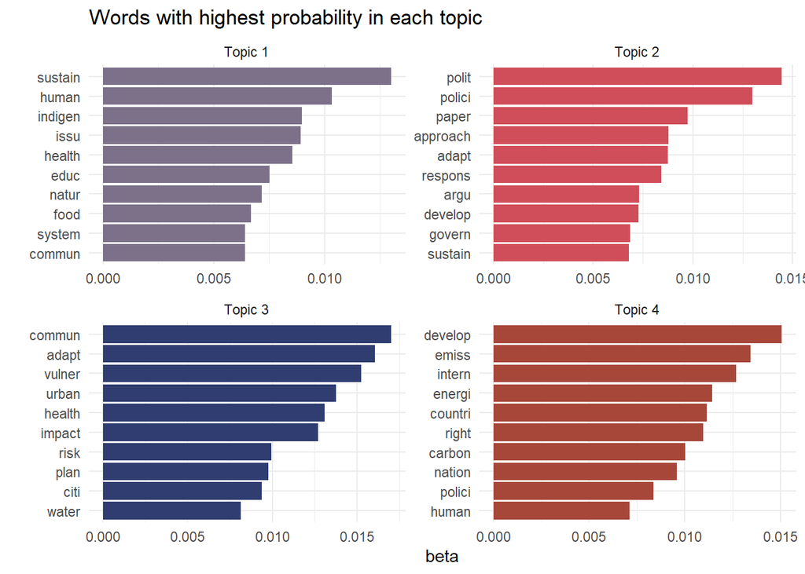

### Topics 5

```
Topic 1 Top Words:
     Highest Prob: adapt, polici, emiss, develop, carbon, countri, mitig
     FREX: emiss, redd, compens, ghg, carbon, forest, budget
     Lift: 43, administ, approach’, avers, barlei, beset, biocapac
     Score: adapt, emiss, carbon, redd, mitig, financ, compens
Topic 2 Top Words:
     Highest Prob: polit, action, movement, understand, frame, discours, power
     FREX: frame, intersect, discours, nepal, scholarship, contest, narr
     Lift: agit, anxiou, apwld, archaeologi, attun, britain, broadsheet
     Score: frame, movement, polit, seal, activist, discours, narr
Topic 3 Top Words:
     Highest Prob: sustain, develop, econom, energi, polici, govern, intern
     FREX: tourism, eu, sdg, divest, sustain, coal, economi
     Lift: 1978, 1995, ab, actant, activist', āina, aloha
     Score: sustain, divest, tourism, economi, green, energi, negoti
Topic 4 Top Words:
     Highest Prob: human, right, indigen, ethic, issu, natur, educ
     FREX: philosophi, creativ, teacher, mathemat, aviat, cours, nonhuman
     Lift: literari, philosophi, 1,000, 1,650, 1.2, 10.1002, 100000
     Score: right, student, indigen, ethic, teach, educ, philosophi
Topic 5 Top Words:
     Highest Prob: health, commun, urban, vulner, impact, citi, risk
     FREX: citi, flood, heat, exposur, resid, sea, weather
     Lift: 35, 61, 65, 69, 76, acr, allerg
     Score: health, urban, flood, heat, exposur, wildfir, censu
```

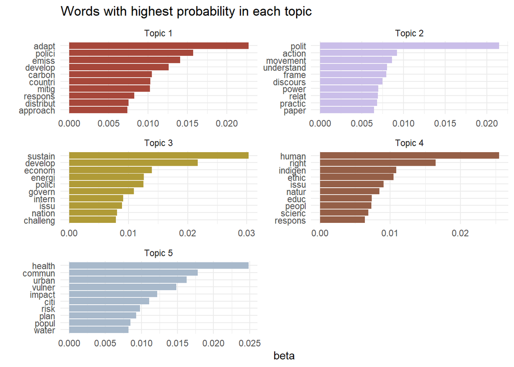

### Topics 6

```
Topic 1 Top Words:
     Highest Prob: emiss, right, intern, countri, respons, human, develop
     FREX: law, legal, unfccc, court, litig, compens, duti
     Lift: 1995, 43, 77, abnorm, aep, amend, angai
     Score: emiss, law, redd, carbon, pari, unfccc, litig
Topic 2 Top Words:
     Highest Prob: health, sustain, human, food, system, environ, develop
     FREX: nurs, covid, chemic, healthi, child, contamin, biolog
     Lift: 05, 07, 1,000, 1,650, 1.2, 100000, 1018
     Score: health, nurs, food, seal, exposur, sdg, compost
Topic 3 Top Words:
     Highest Prob: urban, vulner, commun, citi, risk, impact, water
     FREX: flood, heat, resid, coastal, sea, censu, neighborhood
     Lift: 61, 69, aborigin, ada, adjoin, allerg, ambient
     Score: urban, flood, citi, heat, coastal, censu, wildfir
Topic 4 Top Words:
     Highest Prob: polit, human, ethic, issu, frame, understand, movement
     FREX: essai, philosophi, narr, interdepend, nonhuman, youth, book
     Lift: 1029, 1046, 116, 118, 12th, 144, 160
     Score: student, ethic, divest, educ, book, prince’, narr
Topic 5 Top Words:
     Highest Prob: energi, indigen, polit, econom, develop, movement, economi
     FREX: energi, renew, tourism, capitalist, fossil, transit, fuel
     Lift: redistribut, 0.04, 0.12, 1,474.21, 1,895.41, 104, 120
     Score: energi, fossil, fuel, transit, indigen, economi, ecg
Topic 6 Top Words:
     Highest Prob: adapt, polici, develop, commun, approach, govern, sustain
     FREX: literatur, particip, adapt, review, process, ej, equiti
     Lift: abrupt, attende, bibliometr, burner, cb, ccd, devolv
     Score: adapt, particip, literatur, procedur, daylight, ccd, govern
```

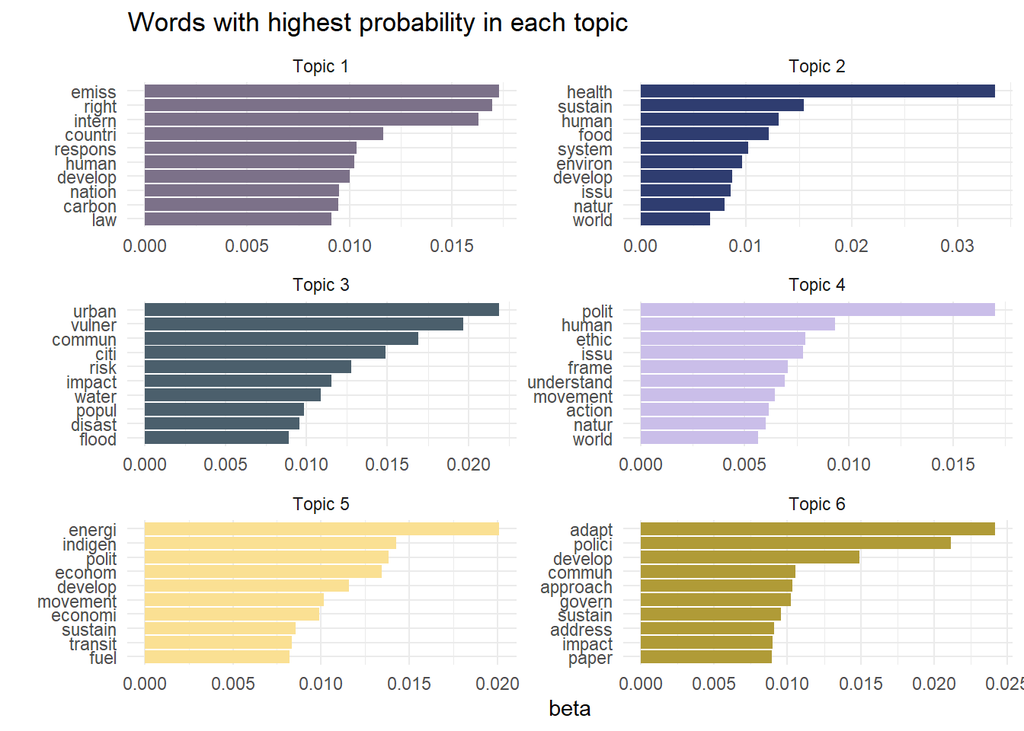

### Topics 7

```
Topic 1 Top Words:
     Highest Prob: health, educ, issu, student, commun, scienc, action
     FREX: student, tourism, teach, nurs, covid, divest, teacher
     Lift: accredit, activist', adolesc, agit, ai, anxiou, biomed
     Score: health, educ, student, nurs, teacher, teach, seal
Topic 2 Top Words:
     Highest Prob: sustain, food, econom, develop, system, agricultur, natur
     FREX: farmer, eco, sdg, crop, soil, agrarian, biolog
     Lift: hopi, marshland, rm, 1987, agrarian, apartheid, biolog
     Score: sustain, agricultur, food, biodivers, farmer, sdg, g
Topic 3 Top Words:
     Highest Prob: polit, ethic, movement, understand, frame, theori, issu
     FREX: philosophi, frame, discours, ethic, theori, narr, polit
     Lift: ander, clement, limin, mayan, islam, literari, ontologi
     Score: ethic, discours, prince’, theori, moral, philosophi, anthropocen
Topic 4 Top Words:
     Highest Prob: adapt, polici, develop, govern, approach, sustain, local
     FREX: adapt, literatur, govern, implement, equiti, capac, polici
     Lift: acf, actant, angai, behav, bibliometr, cb, cbfm
     Score: adapt, redd, procedur, daylight, forest, sustain, polici
Topic 5 Top Words:
     Highest Prob: urban, vulner, commun, citi, risk, water, health
     FREX: flood, heat, resid, censu, urban, citi, exposur
     Lift: 61, 69, adger, adjoin, allerg, ambient, carolina
     Score: urban, flood, heat, citi, exposur, health, wildfir
Topic 6 Top Words:
     Highest Prob: emiss, energi, carbon, countri, develop, polici, mitig
     FREX: emiss, carbon, ghg, cap, debt, energi, solar
     Lift: avers, barlei, confucian, founder, itt, leakag, railroad
     Score: emiss, carbon, energi, pari, ga, greenhous, agreement
Topic 7 Top Words:
     Highest Prob: right, human, indigen, law, peopl, intern, legal
     FREX: court, litig, pacif, right, indigen, law, sid
     Lift: 27, austronesian, backward, cemeteri, cop25, court', courtroom
     Score: right, indigen, law, litig, legal, court, damag
```

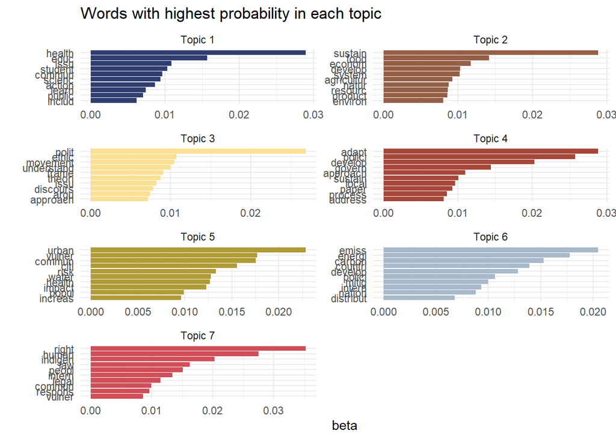

### Topics 8

```
Topic 1 Top Words:
     Highest Prob: sustain, develop, scienc, practic, issu, educ, approach
     FREX: learn, scienc, student, educ, teacher, engin, gender
     Lift: ccd, 112, 1890, 193, 1985, 2015a, 250
     Score: educ, student, learn, sustain, teacher, teach, daylight
Topic 2 Top Words:
     Highest Prob: water, food, resourc, sustain, system, develop, forest
     FREX: food, forest, redd, farmer, biolog, agricultur, water
     Lift: acid, adger, agroecolog, ampl, barlei, campesina, cbfm
     Score: food, forest, water, redd, agricultur, farmer, crop
Topic 3 Top Words:
     Highest Prob: emiss, countri, carbon, develop, polici, mitig, nation
     FREX: cap, tax, emiss, greenhous, trade, ga, carbon
     Lift: 0.12, 1,474.21, 1,895.41, 10,000, 10.2, 1011, 105
     Score: emiss, carbon, greenhous, ga, ghg, cap, tax
Topic 4 Top Words:
     Highest Prob: human, indigen, polit, world, cultur, ecolog, natur
     FREX: tourism, creativ, religion, spiritu, christian, anthropocen, nonhuman
     Lift: 111, 160, 1944, 1948, 1956, 1967, 1969
     Score: indigen, seal, anthropocen, tourism, prince’, ecumen, inuit
Topic 5 Top Words:
     Highest Prob: disast, flood, commun, vulner, heat, level, popul
     FREX: flood, censu, hurrican, wildfir, reloc, tract, heat
     Lift: µg, 0.001, 0.002, 0.006, 0.008, 0.010, 0.013
     Score: flood, wildfir, heat, censu, disast, tract, coastal
Topic 6 Top Words:
     Highest Prob: movement, energi, polit, transit, green, organ, action
     FREX: protest, grassroot, divest, movement, coalit, transit, energi
     Lift: 1,227, 1,663, 1018, 12th, 144, 15.3, 15.400
     Score: movement, energi, divest, activist, protest, transit, youth
Topic 7 Top Words:
     Highest Prob: adapt, health, vulner, commun, urban, impact, plan
     FREX: health, adapt, plan, citi, resili, urban, capac
     Lift: cca, dengu, 05, 1,053, 110, 113, 150,000
     Score: health, adapt, urban, citi, vulner, resili, nurs
Topic 8 Top Words:
     Highest Prob: right, respons, polit, human, intern, argu, govern
     FREX: legal, right, law, claim, moral, norm, litig
     Lift: llc, 100000, 1029, 1046, 116, 118, 148
     Score: right, negoti, law, litig, moral, duti, ethic
```

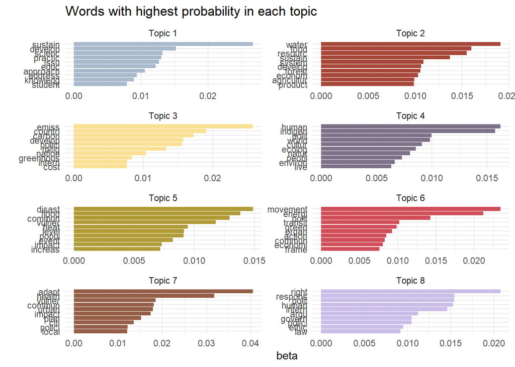

### Topics 9

```
Topic 1 Top Words:
     Highest Prob: water, disast, flood, resourc, region, vulner, risk
     FREX: settlement, drought, flood, disast, migrat, water, hurrican
     Lift: adger, apwld, ca, darl, glacial, ik, intertempor
     Score: flood, water, disast, migrat, drought, coastal, nepal’
Topic 2 Top Words:
     Highest Prob: commun, local, particip, project, govern, action, level
     FREX: divest, commun, particip, local, project, participatori, interview
     Lift: cc, cca, ccd, hei, 1,663, 144, 17,000
     Score: commun, local, divest, particip, ccd, coastal, cbi
Topic 3 Top Words:
     Highest Prob: polit, ethic, action, respons, frame, movement, understand
     FREX: frame, ethic, narr, discours, moral, philosophi, polit
     Lift: 1,227, 10.1002, 12th, 188, 1890, 1944, 1947
     Score: ethic, frame, moral, movement, religi, narr, discours
Topic 4 Top Words:
     Highest Prob: adapt, develop, polici, sustain, approach, urban, citi
     FREX: adapt, literatur, ej, citi, capac, equiti, review
     Lift: aristotelian, bibliometr, ccccjh, emerald, induct, mayan, paraguai
     Score: adapt, urban, citi, plan, daylight, sustain, resili
Topic 5 Top Words:
     Highest Prob: emiss, intern, polici, carbon, countri, develop, nation
     FREX: redd, unfccc, litig, scheme, emiss, pari, negoti
     Lift: 77, approach’, backward, bloc, cancun, canei, cbdr
     Score: emiss, carbon, law, redd, pari, unfccc, negoti
Topic 6 Top Words:
     Highest Prob: energi, educ, scienc, issu, student, transit, gender
     FREX: engin, renew, teacher, teach, energi, student, mathemat
     Lift: anthropologist, authent, broadsheet, criminologi, excel, gcc, ge
     Score: energi, student, educ, engin, teach, teacher, learn
Topic 7 Top Words:
     Highest Prob: indigen, fuel, fossil, world, peopl, movement, live
     FREX: coal, mine, inuit, mother, music, seal, decolon
     Lift: agit, author’, biogeochem, campesina, confucian, est, guilt
     Score: indigen, fossil, coal, seal, inuit, prince’, mine
Topic 8 Top Words:
     Highest Prob: health, urban, impact, vulner, popul, public, risk
     FREX: health, heat, censu, wildfir, exposur, tract, incom
     Lift: hrrlc, pm, summertim, turf, bioethic, cardiovascular, dengu
     Score: health, heat, censu, exposur, tract, wildfir, urban
Topic 9 Top Words:
     Highest Prob: human, sustain, right, econom, system, develop, food
     FREX: labour, tourism, food, economi, right, liber, human
     Lift: agroecolog, bacteri, barlei, behalf, clement, deter, enlighten
     Score: food, right, tourism, sustain, human, ecg, compost
```

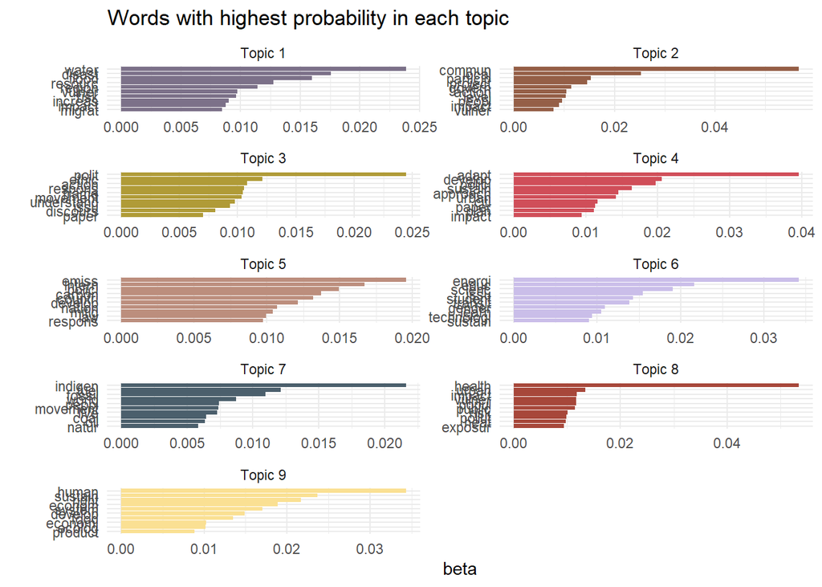

### Topics 10

```
Topic 1 Top Words:
     Highest Prob: health, urban, citi, heat, popul, public, impact
     FREX: heat, toxic, nurs, censu, wildfir, urban, health
     Lift: 10.4, 100,000, 2047, 2051, 21.7, 61, adjoin
     Score: health, urban, heat, citi, censu, exposur, nurs
Topic 2 Top Words:
     Highest Prob: natur, law, issu, resourc, human, nation, indigen
     FREX: mine, ocean, epa, tribal, court, speci, declar
     Lift: 0.04, 1,000, 1,650, 1.2, 100000, 104, 110th
     Score: mine, court, epa, nepal’, law, king, nepal
Topic 3 Top Words:
     Highest Prob: sustain, develop, system, water, food, econom, resourc
     FREX: food, farmer, sdg, sustain, agricultur, gender, water
     Lift: agrobiodivers, ai, bibliometr, compost, concomit, marshland, mayan
     Score: sustain, food, water, agricultur, sdg, farmer, gender
Topic 4 Top Words:
     Highest Prob: educ, human, indigen, student, issu, ethic, scienc
     FREX: student, teach, creativ, teacher, inuit, cours, book
     Lift: author’, dr, eschatologi, guilt, jenkin, laura, leopold
     Score: student, educ, teacher, teach, inuit, book, seal
Topic 5 Top Words:
     Highest Prob: commun, vulner, adapt, risk, plan, local, disast
     FREX: coastal, sea, disast, vulner, flood, resili, reloc
     Lift: abrupt, ada, apwld, cb, cca, ccd, cemeteri
     Score: flood, adapt, coastal, vulner, disast, resili, sea
Topic 6 Top Words:
     Highest Prob: right, intern, human, nation, develop, govern, negoti
     FREX: redd, unfccc, kyoto, negoti, right, legal, regim
     Lift: bloc, cbfm, devolv, eu', galleri, ironi, juliana
     Score: redd, negoti, unfccc, pari, forest, law, right
Topic 7 Top Words:
     Highest Prob: polici, adapt, approach, paper, impact, respons, address
     FREX: literatur, polici, review, equiti, solut, dimens, implic
     Lift: 148, 162, 1969, 290, 3.4, 3e', abm
     Score: adapt, polici, procedur, literatur, approach, equiti, conceptu
Topic 8 Top Words:
     Highest Prob: polit, movement, frame, discours, understand, action, relat
     FREX: feminist, narr, intersect, frame, discours, tourism, domin
     Lift: adorno, agit, anxiou, aristotelian, attun, authent, authorship
     Score: movement, frame, discours, narr, feminist, tourism, daylight
Topic 9 Top Words:
     Highest Prob: energi, carbon, fuel, green, emiss, fossil, transit
     FREX: energi, fossil, divest, sid, aviat, fuel, renew
     Lift: ander, birmingham, britain, csr, decommodif, decoupl, donald
     Score: energi, fossil, carbon, fuel, divest, coal, emiss
Topic 10 Top Words:
     Highest Prob: emiss, countri, principl, respons, ethic, mitig, distribut
     FREX: compens, duti, fair, tax, moral, intergener, alloc
     Lift: 1029, 1046, 116, 118, 194, 2025, 2056
     Score: emiss, duti, compens, moral, carbon, ethic, alloc
```

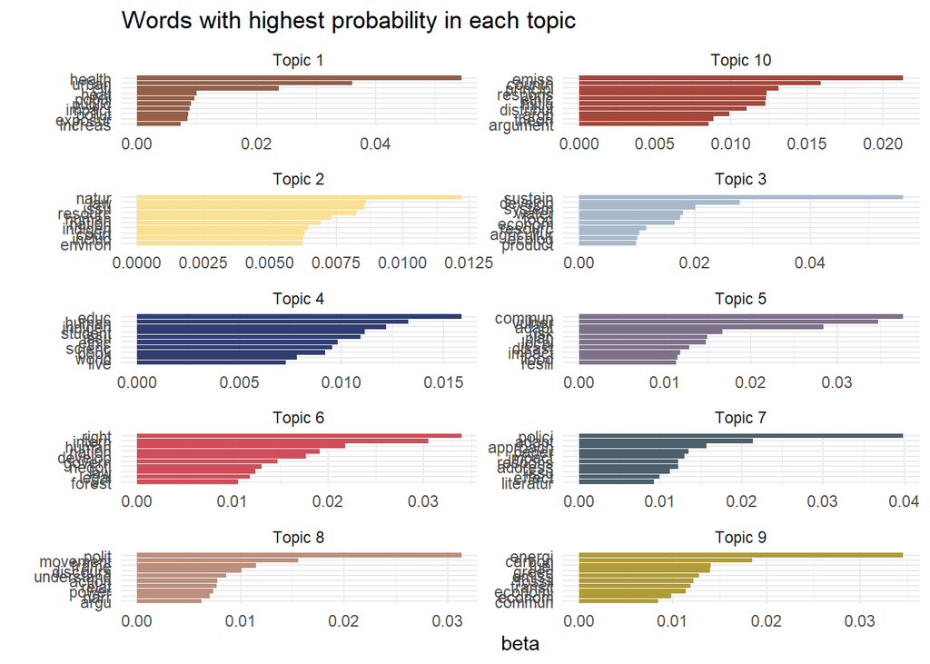

# LDA tuning

Statistical methods for identifying the optimum number of topics.

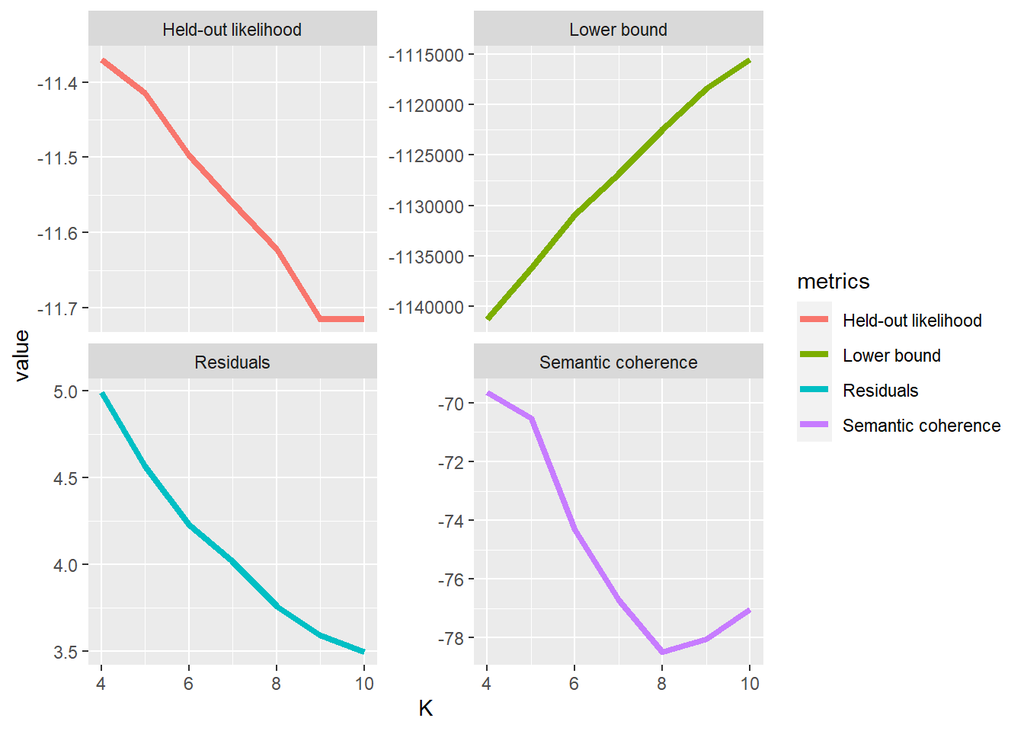

## LDA tuning 2

```
## fit models... done.
## calculate metrics:
##   Griffiths2004... done.
##   CaoJuan2009... done.
##   Arun2010... done.
##   Deveaud2014... done.
```

| topics | Griffiths2004 | CaoJuan2009 | Arun2010 | Deveaud2014 |
| --- | --- | --- | --- | --- |
| Min. : 2 | Min. :-1126232 | Min. :0.03729 | Min. : 966.2 | Min. :2.100 |
| 1st Qu.: 9 | 1st Qu.: -994462 | 1st Qu.:0.04240 | 1st Qu.:1038.1 | 1st Qu.:2.203 |
| Median :16 | Median : -951804 | Median :0.05440 | Median :1152.6 | Median :2.298 |
| Mean :16 | Mean : -975322 | Mean :0.06352 | Mean :1215.0 | Mean :2.283 |
| 3rd Qu.:23 | 3rd Qu.: -942195 | 3rd Qu.:0.07376 | 3rd Qu.:1329.0 | 3rd Qu.:2.355 |
| Max. :30 | Max. : -930299 | Max. :0.15963 | Max. :1806.4 | Max. :2.453 |

## Gamma diagnostics

Checks on the result of Gamma.

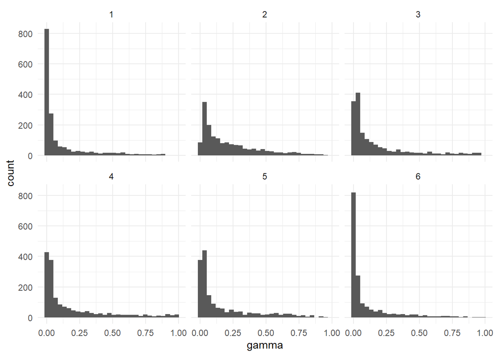

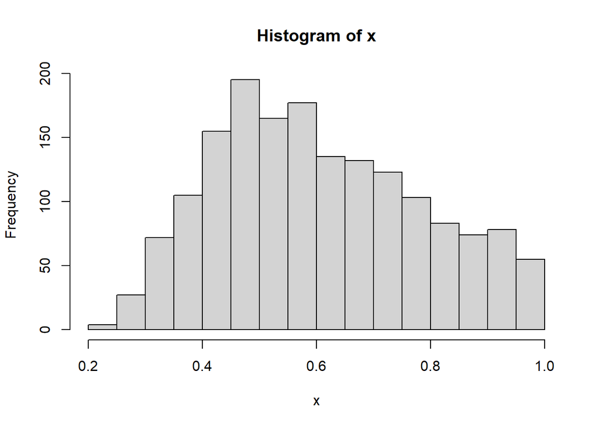

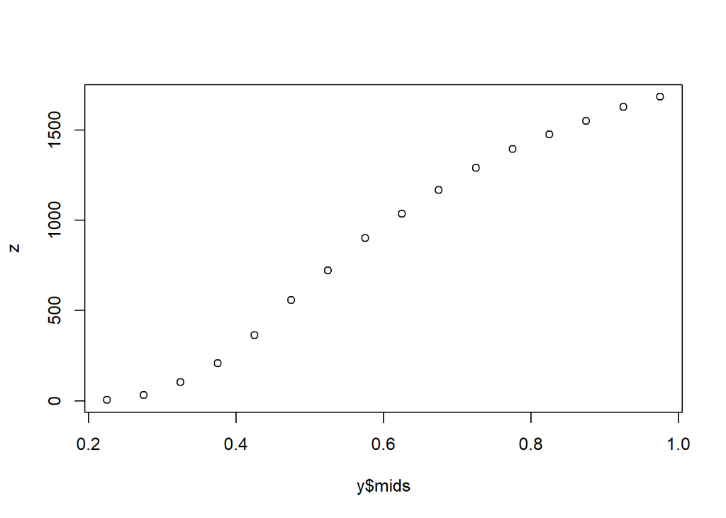